# Risk Factor Analysis

## Outcome Variable

**Outcome Variable:** whz

## Predictor Variables

**Intervention Variable:** predfeed36

**Adjustment Set:**

- arm
- sex
- month
- brthmon
- W_mage
- meducyrs
- feducyrs
- hhwealth_quart
- hfoodsec
- W_mhtcm
- W_mwtkg
- W_mbmi
- vagbrth
- W_gagebrth
- W_birthwt
- W_birthlen
- W_nrooms
- W_nchldlt5
- W_parity
- impfloor
- impsan
- safeh20
- delta_W_mage
- delta_meducyrs
- delta_feducyrs
- delta_hhwealth_quart
- delta_hfoodsec
- delta_W_mhtcm
- delta_W_mwtkg
- delta_W_mbmi
- delta_vagbrth
- delta_W_gagebrth
- delta_W_birthwt
- delta_W_birthlen
- delta_W_nrooms
- delta_W_nchldlt5
- delta_W_parity
- delta_impfloor
- delta_impsan
- delta_safeh20

## Stratifying Variables

The analysis was stratified on these variable(s):

- agecat
- studyid
- country

## Data Summary

| agecat | studyid | country | predfeed36 | n_cell | n |
| --- | --- | --- | --- | --- | --- |
| Birth | ki0047075b-MAL-ED | BANGLADESH | 1 | 69 | 208 |
| Birth | ki0047075b-MAL-ED | BANGLADESH | 0 | 139 | 208 |
| Birth | ki0047075b-MAL-ED | BRAZIL | 1 | 7 | 62 |
| Birth | ki0047075b-MAL-ED | BRAZIL | 0 | 55 | 62 |
| Birth | ki0047075b-MAL-ED | INDIA | 1 | 4 | 40 |
| Birth | ki0047075b-MAL-ED | INDIA | 0 | 36 | 40 |
| Birth | ki0047075b-MAL-ED | NEPAL | 1 | 1 | 25 |
| Birth | ki0047075b-MAL-ED | NEPAL | 0 | 24 | 25 |
| Birth | ki0047075b-MAL-ED | PERU | 1 | 57 | 218 |
| Birth | ki0047075b-MAL-ED | PERU | 0 | 161 | 218 |
| Birth | ki0047075b-MAL-ED | SOUTH AFRICA | 1 | 2 | 104 |
| Birth | ki0047075b-MAL-ED | SOUTH AFRICA | 0 | 102 | 104 |
| Birth | ki0047075b-MAL-ED | TANZANIA, UNITED REPUBLIC OF | 1 | 0 | 111 |
| Birth | ki0047075b-MAL-ED | TANZANIA, UNITED REPUBLIC OF | 0 | 111 | 111 |
| Birth | ki1000109-EE | PAKISTAN | 1 | 2 | 6 |
| Birth | ki1000109-EE | PAKISTAN | 0 | 4 | 6 |
| Birth | ki1113344-GMS-Nepal | NEPAL | 1 | 396 | 491 |
| Birth | ki1113344-GMS-Nepal | NEPAL | 0 | 95 | 491 |
| Birth | kiGH5241-JiVitA-3 | BANGLADESH | 1 | 8205 | 10491 |
| Birth | kiGH5241-JiVitA-3 | BANGLADESH | 0 | 2286 | 10491 |
| Birth | kiGH5241-JiVitA-4 | BANGLADESH | 1 | 1714 | 2128 |
| Birth | kiGH5241-JiVitA-4 | BANGLADESH | 0 | 414 | 2128 |
| 6 months | ki0047075b-MAL-ED | BANGLADESH | 1 | 81 | 240 |
| 6 months | ki0047075b-MAL-ED | BANGLADESH | 0 | 159 | 240 |
| 6 months | ki0047075b-MAL-ED | BRAZIL | 1 | 25 | 209 |
| 6 months | ki0047075b-MAL-ED | BRAZIL | 0 | 184 | 209 |
| 6 months | ki0047075b-MAL-ED | INDIA | 1 | 17 | 233 |
| 6 months | ki0047075b-MAL-ED | INDIA | 0 | 216 | 233 |
| 6 months | ki0047075b-MAL-ED | NEPAL | 1 | 8 | 235 |
| 6 months | ki0047075b-MAL-ED | NEPAL | 0 | 227 | 235 |
| 6 months | ki0047075b-MAL-ED | PERU | 1 | 72 | 272 |
| 6 months | ki0047075b-MAL-ED | PERU | 0 | 200 | 272 |
| 6 months | ki0047075b-MAL-ED | SOUTH AFRICA | 1 | 3 | 250 |
| 6 months | ki0047075b-MAL-ED | SOUTH AFRICA | 0 | 247 | 250 |
| 6 months | ki0047075b-MAL-ED | TANZANIA, UNITED REPUBLIC OF | 1 | 5 | 243 |
| 6 months | ki0047075b-MAL-ED | TANZANIA, UNITED REPUBLIC OF | 0 | 238 | 243 |
| 6 months | ki1000109-EE | PAKISTAN | 1 | 4 | 9 |
| 6 months | ki1000109-EE | PAKISTAN | 0 | 5 | 9 |
| 6 months | ki1000304b-SAS-FoodSuppl | INDIA | 1 | 0 | 168 |
| 6 months | ki1000304b-SAS-FoodSuppl | INDIA | 0 | 168 | 168 |
| 6 months | ki1113344-GMS-Nepal | NEPAL | 1 | 422 | 527 |
| 6 months | ki1113344-GMS-Nepal | NEPAL | 0 | 105 | 527 |
| 6 months | ki1148112-LCNI-5 | MALAWI | 1 | 47 | 272 |
| 6 months | ki1148112-LCNI-5 | MALAWI | 0 | 225 | 272 |
| 6 months | kiGH5241-JiVitA-3 | BANGLADESH | 1 | 6559 | 8516 |
| 6 months | kiGH5241-JiVitA-3 | BANGLADESH | 0 | 1957 | 8516 |
| 6 months | kiGH5241-JiVitA-4 | BANGLADESH | 1 | 3252 | 4188 |
| 6 months | kiGH5241-JiVitA-4 | BANGLADESH | 0 | 936 | 4188 |
| 24 months | ki0047075b-MAL-ED | BANGLADESH | 1 | 69 | 212 |
| 24 months | ki0047075b-MAL-ED | BANGLADESH | 0 | 143 | 212 |
| 24 months | ki0047075b-MAL-ED | BRAZIL | 1 | 20 | 169 |
| 24 months | ki0047075b-MAL-ED | BRAZIL | 0 | 149 | 169 |
| 24 months | ki0047075b-MAL-ED | INDIA | 1 | 17 | 224 |
| 24 months | ki0047075b-MAL-ED | INDIA | 0 | 207 | 224 |
| 24 months | ki0047075b-MAL-ED | NEPAL | 1 | 8 | 227 |
| 24 months | ki0047075b-MAL-ED | NEPAL | 0 | 219 | 227 |
| 24 months | ki0047075b-MAL-ED | PERU | 1 | 53 | 201 |
| 24 months | ki0047075b-MAL-ED | PERU | 0 | 148 | 201 |
| 24 months | ki0047075b-MAL-ED | SOUTH AFRICA | 1 | 3 | 235 |
| 24 months | ki0047075b-MAL-ED | SOUTH AFRICA | 0 | 232 | 235 |
| 24 months | ki0047075b-MAL-ED | TANZANIA, UNITED REPUBLIC OF | 1 | 4 | 213 |
| 24 months | ki0047075b-MAL-ED | TANZANIA, UNITED REPUBLIC OF | 0 | 209 | 213 |
| 24 months | ki1000109-EE | PAKISTAN | 1 | 0 | 3 |
| 24 months | ki1000109-EE | PAKISTAN | 0 | 3 | 3 |
| 24 months | ki1113344-GMS-Nepal | NEPAL | 1 | 362 | 445 |
| 24 months | ki1113344-GMS-Nepal | NEPAL | 0 | 83 | 445 |
| 24 months | ki1148112-LCNI-5 | MALAWI | 1 | 34 | 184 |
| 24 months | ki1148112-LCNI-5 | MALAWI | 0 | 150 | 184 |
| 24 months | kiGH5241-JiVitA-3 | BANGLADESH | 1 | 3297 | 4283 |
| 24 months | kiGH5241-JiVitA-3 | BANGLADESH | 0 | 986 | 4283 |
| 24 months | kiGH5241-JiVitA-4 | BANGLADESH | 1 | 3144 | 4035 |
| 24 months | kiGH5241-JiVitA-4 | BANGLADESH | 0 | 891 | 4035 |

The following strata were considered:

- agecat: 24 months, studyid: ki0047075b-MAL-ED, country: BANGLADESH
- agecat: 24 months, studyid: ki0047075b-MAL-ED, country: BRAZIL
- agecat: 24 months, studyid: ki0047075b-MAL-ED, country: INDIA
- agecat: 24 months, studyid: ki0047075b-MAL-ED, country: NEPAL
- agecat: 24 months, studyid: ki0047075b-MAL-ED, country: PERU
- agecat: 24 months, studyid: ki0047075b-MAL-ED, country: SOUTH AFRICA
- agecat: 24 months, studyid: ki0047075b-MAL-ED, country: TANZANIA, UNITED REPUBLIC OF
- agecat: 24 months, studyid: ki1000109-EE, country: PAKISTAN
- agecat: 24 months, studyid: ki1113344-GMS-Nepal, country: NEPAL
- agecat: 24 months, studyid: ki1148112-LCNI-5, country: MALAWI
- agecat: 24 months, studyid: kiGH5241-JiVitA-3, country: BANGLADESH
- agecat: 24 months, studyid: kiGH5241-JiVitA-4, country: BANGLADESH
- agecat: 6 months, studyid: ki0047075b-MAL-ED, country: BANGLADESH
- agecat: 6 months, studyid: ki0047075b-MAL-ED, country: BRAZIL
- agecat: 6 months, studyid: ki0047075b-MAL-ED, country: INDIA
- agecat: 6 months, studyid: ki0047075b-MAL-ED, country: NEPAL
- agecat: 6 months, studyid: ki0047075b-MAL-ED, country: PERU
- agecat: 6 months, studyid: ki0047075b-MAL-ED, country: SOUTH AFRICA
- agecat: 6 months, studyid: ki0047075b-MAL-ED, country: TANZANIA, UNITED REPUBLIC OF
- agecat: 6 months, studyid: ki1000109-EE, country: PAKISTAN
- agecat: 6 months, studyid: ki1000304b-SAS-FoodSuppl, country: INDIA
- agecat: 6 months, studyid: ki1113344-GMS-Nepal, country: NEPAL
- agecat: 6 months, studyid: ki1148112-LCNI-5, country: MALAWI
- agecat: 6 months, studyid: kiGH5241-JiVitA-3, country: BANGLADESH
- agecat: 6 months, studyid: kiGH5241-JiVitA-4, country: BANGLADESH
- agecat: Birth, studyid: ki0047075b-MAL-ED, country: BANGLADESH
- agecat: Birth, studyid: ki0047075b-MAL-ED, country: BRAZIL
- agecat: Birth, studyid: ki0047075b-MAL-ED, country: INDIA
- agecat: Birth, studyid: ki0047075b-MAL-ED, country: NEPAL
- agecat: Birth, studyid: ki0047075b-MAL-ED, country: PERU
- agecat: Birth, studyid: ki0047075b-MAL-ED, country: SOUTH AFRICA
- agecat: Birth, studyid: ki0047075b-MAL-ED, country: TANZANIA, UNITED REPUBLIC OF
- agecat: Birth, studyid: ki1000109-EE, country: PAKISTAN
- agecat: Birth, studyid: ki1113344-GMS-Nepal, country: NEPAL
- agecat: Birth, studyid: kiGH5241-JiVitA-3, country: BANGLADESH
- agecat: Birth, studyid: kiGH5241-JiVitA-4, country: BANGLADESH

### Dropped Strata

Some strata were dropped due to rare outcomes:

- agecat: Birth, studyid: ki0047075b-MAL-ED, country: INDIA
- agecat: Birth, studyid: ki0047075b-MAL-ED, country: NEPAL
- agecat: Birth, studyid: ki0047075b-MAL-ED, country: SOUTH AFRICA
- agecat: Birth, studyid: ki0047075b-MAL-ED, country: TANZANIA, UNITED REPUBLIC OF
- agecat: Birth, studyid: ki1000109-EE, country: PAKISTAN
- agecat: 6 months, studyid: ki0047075b-MAL-ED, country: SOUTH AFRICA
- agecat: 6 months, studyid: ki1000109-EE, country: PAKISTAN
- agecat: 6 months, studyid: ki1000304b-SAS-FoodSuppl, country: INDIA
- agecat: 24 months, studyid: ki0047075b-MAL-ED, country: SOUTH AFRICA
- agecat: 24 months, studyid: ki0047075b-MAL-ED, country: TANZANIA, UNITED REPUBLIC OF
- agecat: 24 months, studyid: ki1000109-EE, country: PAKISTAN

## Methods Detail

We’re interested in the causal parameters $E[Y_a]$ for all values of $a \in \mathcal{A}$. These parameters represent the mean outcome if, possibly contrary to fact, we intervened to set all units to have $A=a$. Under the randomization and positivity assumptions, these are identified by the statistical parameters $\psi_a=E_W[E_{Y|A,W}(Y|A=a,W)]$. In addition, we’re interested in the mean of $Y$, $E[Y]$ under no intervention (the observed mean). We will estimate these parameters by using SuperLearner to fit the relevant likelihood factors – $E_{Y|A,W}(Y|A=a,W)$ and $p(A=a|W)$, and then updating our likelihood fit using a joint TMLE.

For unadjusted analyses ($W=\{\}$), initial likelihoods were estimated using Lrnr_glm to estimate the simple $E(Y|A)$ and Lrnr_mean to estimate $p(A)$. For adjusted analyses, a small library containing Lrnr_glmnet, Lrnr_xgboost, and Lrnr_mean was used.

Having estimated these parameters, we will then use the delta method to estimate relative risks and attributable risks relative to a prespecified baseline level of $A$.

# Results Detail

## Results Plots

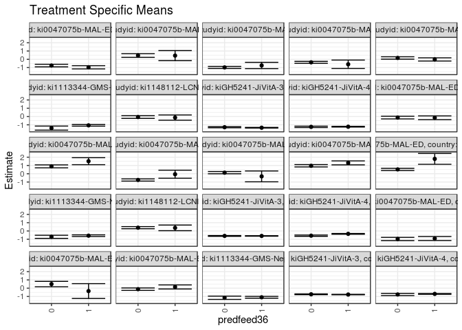

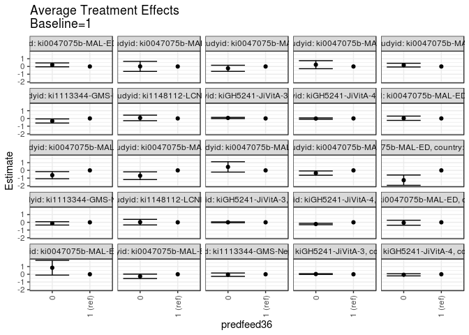

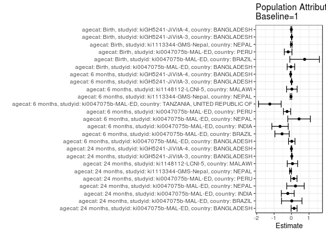

## Results Table

### Parameter: TSM

| agecat | studyid | country | intervention_level | baseline_level | estimate | ci_lower | ci_upper |
| --- | --- | --- | --- | --- | --- | --- | --- |
| Birth | ki0047075b-MAL-ED | BANGLADESH | 1 | NA | -0.9121076 | -1.1531154 | -0.6710998 |
| Birth | ki0047075b-MAL-ED | BANGLADESH | 0 | NA | -0.9659334 | -1.1600085 | -0.7718582 |
| Birth | ki0047075b-MAL-ED | BRAZIL | 1 | NA | -0.3457143 | -1.2397629 | 0.5483343 |
| Birth | ki0047075b-MAL-ED | BRAZIL | 0 | NA | 0.4981818 | 0.1725808 | 0.8237829 |
| Birth | ki0047075b-MAL-ED | PERU | 1 | NA | 0.1488806 | -0.0951403 | 0.3929016 |
| Birth | ki0047075b-MAL-ED | PERU | 0 | NA | -0.1159928 | -0.2629591 | 0.0309734 |
| Birth | ki1113344-GMS-Nepal | NEPAL | 1 | NA | -1.0976455 | -1.2066328 | -0.9886582 |
| Birth | ki1113344-GMS-Nepal | NEPAL | 0 | NA | -1.1534242 | -1.3528072 | -0.9540412 |
| Birth | kiGH5241-JiVitA-3 | BANGLADESH | 1 | NA | -0.7664453 | -0.7923002 | -0.7405904 |
| Birth | kiGH5241-JiVitA-3 | BANGLADESH | 0 | NA | -0.7372433 | -0.7819380 | -0.6925486 |
| Birth | kiGH5241-JiVitA-4 | BANGLADESH | 1 | NA | -0.6890498 | -0.7449692 | -0.6331305 |
| Birth | kiGH5241-JiVitA-4 | BANGLADESH | 0 | NA | -0.7566455 | -0.8907332 | -0.6225577 |
| 6 months | ki0047075b-MAL-ED | BANGLADESH | 1 | NA | -0.1474926 | -0.3733904 | 0.0784052 |
| 6 months | ki0047075b-MAL-ED | BANGLADESH | 0 | NA | -0.1266164 | -0.2869957 | 0.0337628 |
| 6 months | ki0047075b-MAL-ED | BRAZIL | 1 | NA | 1.5151233 | 1.0909331 | 1.9393135 |
| 6 months | ki0047075b-MAL-ED | BRAZIL | 0 | NA | 0.8921438 | 0.7147769 | 1.0695106 |
| 6 months | ki0047075b-MAL-ED | INDIA | 1 | NA | -0.0574289 | -0.5409738 | 0.4261160 |
| 6 months | ki0047075b-MAL-ED | INDIA | 0 | NA | -0.7501237 | -0.8816572 | -0.6185902 |
| 6 months | ki0047075b-MAL-ED | NEPAL | 1 | NA | -0.3168750 | -0.9708901 | 0.3371401 |
| 6 months | ki0047075b-MAL-ED | NEPAL | 0 | NA | 0.1298532 | -0.0040807 | 0.2637870 |
| 6 months | ki0047075b-MAL-ED | PERU | 1 | NA | 1.3115848 | 1.0733738 | 1.5497958 |
| 6 months | ki0047075b-MAL-ED | PERU | 0 | NA | 0.9592435 | 0.8190263 | 1.0994606 |
| 6 months | ki0047075b-MAL-ED | TANZANIA, UNITED REPUBLIC OF | 1 | NA | 1.7950000 | 1.1425391 | 2.4474609 |
| 6 months | ki0047075b-MAL-ED | TANZANIA, UNITED REPUBLIC OF | 0 | NA | 0.5246709 | 0.3926689 | 0.6566728 |
| 6 months | ki1113344-GMS-Nepal | NEPAL | 1 | NA | -0.5676612 | -0.6685357 | -0.4667867 |
| 6 months | ki1113344-GMS-Nepal | NEPAL | 0 | NA | -0.7054370 | -0.8953494 | -0.5155245 |
| 6 months | ki1148112-LCNI-5 | MALAWI | 1 | NA | 0.3751622 | 0.0355730 | 0.7147514 |
| 6 months | ki1148112-LCNI-5 | MALAWI | 0 | NA | 0.3962321 | 0.2695466 | 0.5229175 |
| 6 months | kiGH5241-JiVitA-3 | BANGLADESH | 1 | NA | -0.5999250 | -0.6291033 | -0.5707467 |
| 6 months | kiGH5241-JiVitA-3 | BANGLADESH | 0 | NA | -0.5972894 | -0.6458825 | -0.5486964 |
| 6 months | kiGH5241-JiVitA-4 | BANGLADESH | 1 | NA | -0.3460466 | -0.3920625 | -0.3000307 |
| 6 months | kiGH5241-JiVitA-4 | BANGLADESH | 0 | NA | -0.5666518 | -0.6450112 | -0.4882925 |
| 24 months | ki0047075b-MAL-ED | BANGLADESH | 1 | NA | -0.9656830 | -1.1606416 | -0.7707243 |
| 24 months | ki0047075b-MAL-ED | BANGLADESH | 0 | NA | -0.7570398 | -0.9138265 | -0.6002531 |
| 24 months | ki0047075b-MAL-ED | BRAZIL | 1 | NA | 0.4474878 | -0.1602370 | 1.0552126 |
| 24 months | ki0047075b-MAL-ED | BRAZIL | 0 | NA | 0.4588826 | 0.2368231 | 0.6809422 |
| 24 months | ki0047075b-MAL-ED | INDIA | 1 | NA | -0.7425609 | -1.1196549 | -0.3654668 |
| 24 months | ki0047075b-MAL-ED | INDIA | 0 | NA | -0.9791201 | -1.1014889 | -0.8567512 |
| 24 months | ki0047075b-MAL-ED | NEPAL | 1 | NA | -0.5987500 | -1.1044659 | -0.0930341 |
| 24 months | ki0047075b-MAL-ED | NEPAL | 0 | NA | -0.3659361 | -0.4823082 | -0.2495640 |
| 24 months | ki0047075b-MAL-ED | PERU | 1 | NA | -0.0131727 | -0.2071248 | 0.1807794 |
| 24 months | ki0047075b-MAL-ED | PERU | 0 | NA | 0.1621893 | 0.0164530 | 0.3079257 |
| 24 months | ki1113344-GMS-Nepal | NEPAL | 1 | NA | -1.0649118 | -1.1635365 | -0.9662870 |
| 24 months | ki1113344-GMS-Nepal | NEPAL | 0 | NA | -1.3971502 | -1.6443073 | -1.1499932 |
| 24 months | ki1148112-LCNI-5 | MALAWI | 1 | NA | -0.1292288 | -0.4441072 | 0.1856497 |
| 24 months | ki1148112-LCNI-5 | MALAWI | 0 | NA | -0.0634584 | -0.2244336 | 0.0975168 |
| 24 months | kiGH5241-JiVitA-3 | BANGLADESH | 1 | NA | -1.3504950 | -1.3894446 | -1.3115454 |
| 24 months | kiGH5241-JiVitA-3 | BANGLADESH | 0 | NA | -1.2901551 | -1.3578606 | -1.2224495 |
| 24 months | kiGH5241-JiVitA-4 | BANGLADESH | 1 | NA | -1.2293020 | -1.2709226 | -1.1876813 |
| 24 months | kiGH5241-JiVitA-4 | BANGLADESH | 0 | NA | -1.2469282 | -1.3282051 | -1.1656513 |

### Parameter: E(Y)

| agecat | studyid | country | intervention_level | baseline_level | estimate | ci_lower | ci_upper |
| --- | --- | --- | --- | --- | --- | --- | --- |
| Birth | ki0047075b-MAL-ED | BANGLADESH | NA | NA | -0.9474038 | -1.0929246 | -0.8018831 |
| Birth | ki0047075b-MAL-ED | BRAZIL | NA | NA | 0.4029032 | 0.0896793 | 0.7161272 |
| Birth | ki0047075b-MAL-ED | PERU | NA | NA | -0.0458257 | -0.1696487 | 0.0779973 |
| Birth | ki1113344-GMS-Nepal | NEPAL | NA | NA | -1.1085743 | -1.2077878 | -1.0093609 |
| Birth | kiGH5241-JiVitA-3 | BANGLADESH | NA | NA | -0.7602278 | -0.7829387 | -0.7375169 |
| Birth | kiGH5241-JiVitA-4 | BANGLADESH | NA | NA | -0.7018985 | -0.7560164 | -0.6477806 |
| 6 months | ki0047075b-MAL-ED | BANGLADESH | NA | NA | -0.1361806 | -0.2655204 | -0.0068407 |
| 6 months | ki0047075b-MAL-ED | BRAZIL | NA | NA | 0.9717225 | 0.8073791 | 1.1360658 |
| 6 months | ki0047075b-MAL-ED | INDIA | NA | NA | -0.7164664 | -0.8440835 | -0.5888492 |
| 6 months | ki0047075b-MAL-ED | NEPAL | NA | NA | 0.1146454 | -0.0170405 | 0.2463313 |
| 6 months | ki0047075b-MAL-ED | PERU | NA | NA | 1.0551961 | 0.9331945 | 1.1771976 |
| 6 months | ki0047075b-MAL-ED | TANZANIA, UNITED REPUBLIC OF | NA | NA | 0.5508093 | 0.4191033 | 0.6825154 |
| 6 months | ki1113344-GMS-Nepal | NEPAL | NA | NA | -0.6001075 | -0.6890924 | -0.5111227 |
| 6 months | ki1148112-LCNI-5 | MALAWI | NA | NA | 0.3925000 | 0.2735307 | 0.5114693 |
| 6 months | kiGH5241-JiVitA-3 | BANGLADESH | NA | NA | -0.5994135 | -0.6250748 | -0.5737521 |
| 6 months | kiGH5241-JiVitA-4 | BANGLADESH | NA | NA | -0.3960017 | -0.4356255 | -0.3563778 |
| 24 months | ki0047075b-MAL-ED | BANGLADESH | NA | NA | -0.8201887 | -0.9423967 | -0.6979806 |
| 24 months | ki0047075b-MAL-ED | BRAZIL | NA | NA | 0.4592308 | 0.2528453 | 0.6656163 |
| 24 months | ki0047075b-MAL-ED | INDIA | NA | NA | -0.9587723 | -1.0752995 | -0.8422452 |
| 24 months | ki0047075b-MAL-ED | NEPAL | NA | NA | -0.3741410 | -0.4879554 | -0.2603265 |
| 24 months | ki0047075b-MAL-ED | PERU | NA | NA | 0.1204478 | 0.0005049 | 0.2403906 |
| 24 months | ki1113344-GMS-Nepal | NEPAL | NA | NA | -1.1236255 | -1.2167712 | -1.0304797 |
| 24 months | ki1148112-LCNI-5 | MALAWI | NA | NA | -0.0770652 | -0.2204213 | 0.0662909 |
| 24 months | kiGH5241-JiVitA-3 | BANGLADESH | NA | NA | -1.3365001 | -1.3704041 | -1.3025961 |
| 24 months | kiGH5241-JiVitA-4 | BANGLADESH | NA | NA | -1.2344089 | -1.2708428 | -1.1979750 |

### Parameter: ATE

| agecat | studyid | country | intervention_level | baseline_level | estimate | ci_lower | ci_upper |
| --- | --- | --- | --- | --- | --- | --- | --- |
| Birth | ki0047075b-MAL-ED | BANGLADESH | 1 | 1 | 0.0000000 | 0.0000000 | 0.0000000 |
| Birth | ki0047075b-MAL-ED | BANGLADESH | 0 | 1 | -0.0538258 | -0.3747178 | 0.2670663 |
| Birth | ki0047075b-MAL-ED | BRAZIL | 1 | 1 | 0.0000000 | 0.0000000 | 0.0000000 |
| Birth | ki0047075b-MAL-ED | BRAZIL | 0 | 1 | 0.8438961 | -0.1075969 | 1.7953891 |
| Birth | ki0047075b-MAL-ED | PERU | 1 | 1 | 0.0000000 | 0.0000000 | 0.0000000 |
| Birth | ki0047075b-MAL-ED | PERU | 0 | 1 | -0.2648735 | -0.5503941 | 0.0206471 |
| Birth | ki1113344-GMS-Nepal | NEPAL | 1 | 1 | 0.0000000 | 0.0000000 | 0.0000000 |
| Birth | ki1113344-GMS-Nepal | NEPAL | 0 | 1 | -0.0557787 | -0.2741684 | 0.1626109 |
| Birth | kiGH5241-JiVitA-3 | BANGLADESH | 1 | 1 | 0.0000000 | 0.0000000 | 0.0000000 |
| Birth | kiGH5241-JiVitA-3 | BANGLADESH | 0 | 1 | 0.0292020 | -0.0216794 | 0.0800834 |
| Birth | kiGH5241-JiVitA-4 | BANGLADESH | 1 | 1 | 0.0000000 | 0.0000000 | 0.0000000 |
| Birth | kiGH5241-JiVitA-4 | BANGLADESH | 0 | 1 | -0.0675956 | -0.2086664 | 0.0734751 |
| 6 months | ki0047075b-MAL-ED | BANGLADESH | 1 | 1 | 0.0000000 | 0.0000000 | 0.0000000 |
| 6 months | ki0047075b-MAL-ED | BANGLADESH | 0 | 1 | 0.0208762 | -0.2556630 | 0.2974153 |
| 6 months | ki0047075b-MAL-ED | BRAZIL | 1 | 1 | 0.0000000 | 0.0000000 | 0.0000000 |
| 6 months | ki0047075b-MAL-ED | BRAZIL | 0 | 1 | -0.6229796 | -1.0823474 | -0.1636117 |
| 6 months | ki0047075b-MAL-ED | INDIA | 1 | 1 | 0.0000000 | 0.0000000 | 0.0000000 |
| 6 months | ki0047075b-MAL-ED | INDIA | 0 | 1 | -0.6926948 | -1.1922328 | -0.1931569 |
| 6 months | ki0047075b-MAL-ED | NEPAL | 1 | 1 | 0.0000000 | 0.0000000 | 0.0000000 |
| 6 months | ki0047075b-MAL-ED | NEPAL | 0 | 1 | 0.4467282 | -0.2208600 | 1.1143163 |
| 6 months | ki0047075b-MAL-ED | PERU | 1 | 1 | 0.0000000 | 0.0000000 | 0.0000000 |
| 6 months | ki0047075b-MAL-ED | PERU | 0 | 1 | -0.3523414 | -0.6288160 | -0.0758667 |
| 6 months | ki0047075b-MAL-ED | TANZANIA, UNITED REPUBLIC OF | 1 | 1 | 0.0000000 | 0.0000000 | 0.0000000 |
| 6 months | ki0047075b-MAL-ED | TANZANIA, UNITED REPUBLIC OF | 0 | 1 | -1.2703291 | -1.9360090 | -0.6046493 |
| 6 months | ki1113344-GMS-Nepal | NEPAL | 1 | 1 | 0.0000000 | 0.0000000 | 0.0000000 |
| 6 months | ki1113344-GMS-Nepal | NEPAL | 0 | 1 | -0.1377758 | -0.3530458 | 0.0774943 |
| 6 months | ki1148112-LCNI-5 | MALAWI | 1 | 1 | 0.0000000 | 0.0000000 | 0.0000000 |
| 6 months | ki1148112-LCNI-5 | MALAWI | 0 | 1 | 0.0210698 | -0.3415019 | 0.3836416 |
| 6 months | kiGH5241-JiVitA-3 | BANGLADESH | 1 | 1 | 0.0000000 | 0.0000000 | 0.0000000 |
| 6 months | kiGH5241-JiVitA-3 | BANGLADESH | 0 | 1 | 0.0026356 | -0.0526103 | 0.0578814 |
| 6 months | kiGH5241-JiVitA-4 | BANGLADESH | 1 | 1 | 0.0000000 | 0.0000000 | 0.0000000 |
| 6 months | kiGH5241-JiVitA-4 | BANGLADESH | 0 | 1 | -0.2206052 | -0.3105929 | -0.1306176 |
| 24 months | ki0047075b-MAL-ED | BANGLADESH | 1 | 1 | 0.0000000 | 0.0000000 | 0.0000000 |
| 24 months | ki0047075b-MAL-ED | BANGLADESH | 0 | 1 | 0.2086432 | -0.0433314 | 0.4606177 |
| 24 months | ki0047075b-MAL-ED | BRAZIL | 1 | 1 | 0.0000000 | 0.0000000 | 0.0000000 |
| 24 months | ki0047075b-MAL-ED | BRAZIL | 0 | 1 | 0.0113949 | -0.6365517 | 0.6593414 |
| 24 months | ki0047075b-MAL-ED | INDIA | 1 | 1 | 0.0000000 | 0.0000000 | 0.0000000 |
| 24 months | ki0047075b-MAL-ED | INDIA | 0 | 1 | -0.2365592 | -0.6330104 | 0.1598920 |
| 24 months | ki0047075b-MAL-ED | NEPAL | 1 | 1 | 0.0000000 | 0.0000000 | 0.0000000 |
| 24 months | ki0047075b-MAL-ED | NEPAL | 0 | 1 | 0.2328139 | -0.2861187 | 0.7517465 |
| 24 months | ki0047075b-MAL-ED | PERU | 1 | 1 | 0.0000000 | 0.0000000 | 0.0000000 |
| 24 months | ki0047075b-MAL-ED | PERU | 0 | 1 | 0.1753621 | -0.0679542 | 0.4186784 |
| 24 months | ki1113344-GMS-Nepal | NEPAL | 1 | 1 | 0.0000000 | 0.0000000 | 0.0000000 |
| 24 months | ki1113344-GMS-Nepal | NEPAL | 0 | 1 | -0.3322384 | -0.5985798 | -0.0658971 |
| 24 months | ki1148112-LCNI-5 | MALAWI | 1 | 1 | 0.0000000 | 0.0000000 | 0.0000000 |
| 24 months | ki1148112-LCNI-5 | MALAWI | 0 | 1 | 0.0657703 | -0.2903618 | 0.4219024 |
| 24 months | kiGH5241-JiVitA-3 | BANGLADESH | 1 | 1 | 0.0000000 | 0.0000000 | 0.0000000 |
| 24 months | kiGH5241-JiVitA-3 | BANGLADESH | 0 | 1 | 0.0603399 | -0.0172663 | 0.1379461 |
| 24 months | kiGH5241-JiVitA-4 | BANGLADESH | 1 | 1 | 0.0000000 | 0.0000000 | 0.0000000 |
| 24 months | kiGH5241-JiVitA-4 | BANGLADESH | 0 | 1 | -0.0176262 | -0.1070670 | 0.0718145 |

### Parameter: PAR

| agecat | studyid | country | intervention_level | baseline_level | estimate | ci_lower | ci_upper |
| --- | --- | --- | --- | --- | --- | --- | --- |
| Birth | ki0047075b-MAL-ED | BANGLADESH | 1 | NA | -0.0352963 | -0.2515894 | 0.1809969 |
| Birth | ki0047075b-MAL-ED | BRAZIL | 1 | NA | 0.7486175 | -0.0981055 | 1.5953405 |
| Birth | ki0047075b-MAL-ED | PERU | 1 | NA | -0.1947063 | -0.4135804 | 0.0241678 |
| Birth | ki1113344-GMS-Nepal | NEPAL | 1 | NA | -0.0109289 | -0.0530487 | 0.0311910 |
| Birth | kiGH5241-JiVitA-3 | BANGLADESH | 1 | NA | 0.0062175 | -0.0048651 | 0.0173001 |
| Birth | kiGH5241-JiVitA-4 | BANGLADESH | 1 | NA | -0.0128487 | -0.0408887 | 0.0151914 |
| 6 months | ki0047075b-MAL-ED | BANGLADESH | 1 | NA | 0.0113120 | -0.1743702 | 0.1969943 |
| 6 months | ki0047075b-MAL-ED | BRAZIL | 1 | NA | -0.5434008 | -0.9544759 | -0.1323257 |
| 6 months | ki0047075b-MAL-ED | INDIA | 1 | NA | -0.6590375 | -1.1268751 | -0.1911999 |
| 6 months | ki0047075b-MAL-ED | NEPAL | 1 | NA | 0.4315204 | -0.2134249 | 1.0764657 |
| 6 months | ki0047075b-MAL-ED | PERU | 1 | NA | -0.2563887 | -0.4611883 | -0.0515892 |
| 6 months | ki0047075b-MAL-ED | TANZANIA, UNITED REPUBLIC OF | 1 | NA | -1.2441907 | -1.8936261 | -0.5947552 |
| 6 months | ki1113344-GMS-Nepal | NEPAL | 1 | NA | -0.0324463 | -0.0751842 | 0.0102915 |
| 6 months | ki1148112-LCNI-5 | MALAWI | 1 | NA | 0.0173378 | -0.2851821 | 0.3198577 |
| 6 months | kiGH5241-JiVitA-3 | BANGLADESH | 1 | NA | 0.0005115 | -0.0121729 | 0.0131960 |
| 6 months | kiGH5241-JiVitA-4 | BANGLADESH | 1 | NA | -0.0499551 | -0.0720382 | -0.0278719 |
| 24 months | ki0047075b-MAL-ED | BANGLADESH | 1 | NA | 0.1454943 | -0.0255838 | 0.3165723 |
| 24 months | ki0047075b-MAL-ED | BRAZIL | 1 | NA | 0.0117430 | -0.5734704 | 0.5969564 |
| 24 months | ki0047075b-MAL-ED | INDIA | 1 | NA | -0.2162115 | -0.5841744 | 0.1517515 |
| 24 months | ki0047075b-MAL-ED | NEPAL | 1 | NA | 0.2246090 | -0.2760665 | 0.7252846 |
| 24 months | ki0047075b-MAL-ED | PERU | 1 | NA | 0.1336205 | -0.0475955 | 0.3148364 |
| 24 months | ki1113344-GMS-Nepal | NEPAL | 1 | NA | -0.0587137 | -0.1095582 | -0.0078692 |
| 24 months | ki1148112-LCNI-5 | MALAWI | 1 | NA | 0.0521635 | -0.2445686 | 0.3488957 |
| 24 months | kiGH5241-JiVitA-3 | BANGLADESH | 1 | NA | 0.0139949 | -0.0038491 | 0.0318389 |
| 24 months | kiGH5241-JiVitA-4 | BANGLADESH | 1 | NA | -0.0051069 | -0.0249062 | 0.0146923 |